# NAPED — Portfólio de Ações | Fevereiro 2026

Afya São João del Rei

Portfólio de Ações  
NAPED

Fevereiro de 2026

Registro das iniciativas desenvolvidas pelo Núcleo de Apoio Pedagógico e Experiência Docente.

Ação 1Fevereiro 2026

Encontro com Professores Médicos para Alinhamento Semestral

Integração Docente

Reuniões realizadas com os professores do curso de Medicina para alinhamento das atividades do semestre, apresentação de orientações acadêmicas e fortalecimento da integração entre docentes médicos e NAPED.

Professores médicos, alinhamento do semestre, integração institucional.

Medicina

Evidências

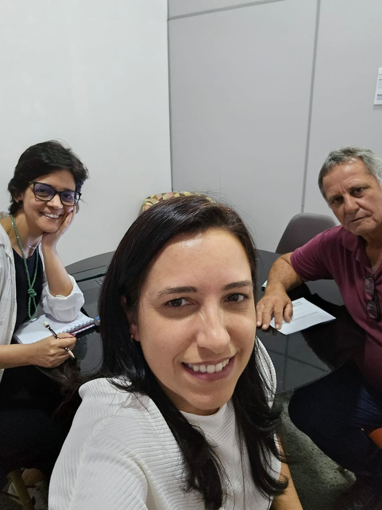

Professor Celso Lasmar

Clínica Cirúrgica

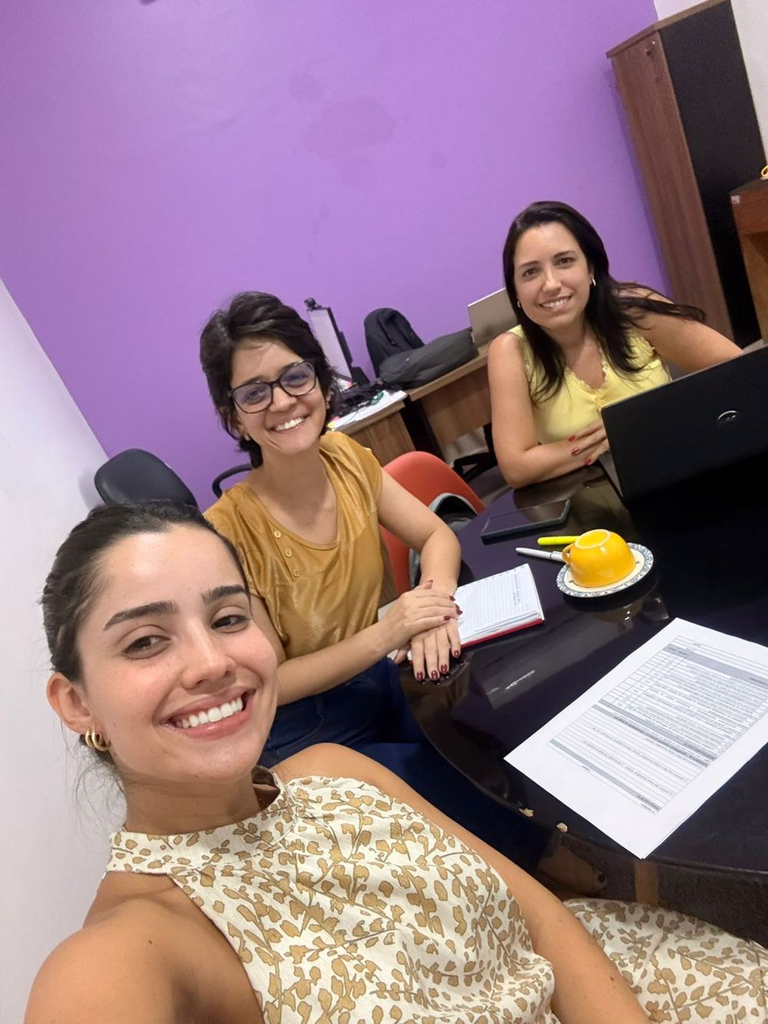

Professora Ana Luiza

Clínicas Integradas, Hellen e Alessandra

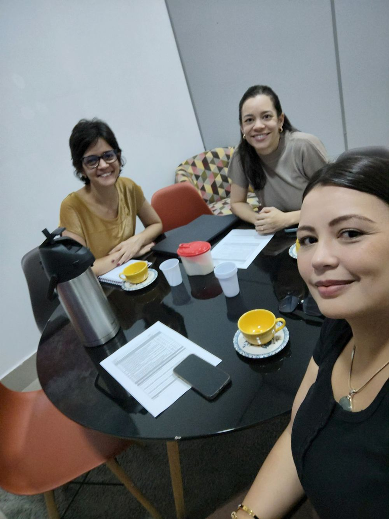

Médicas Laís e Ana Clara

Clínicas Integradas

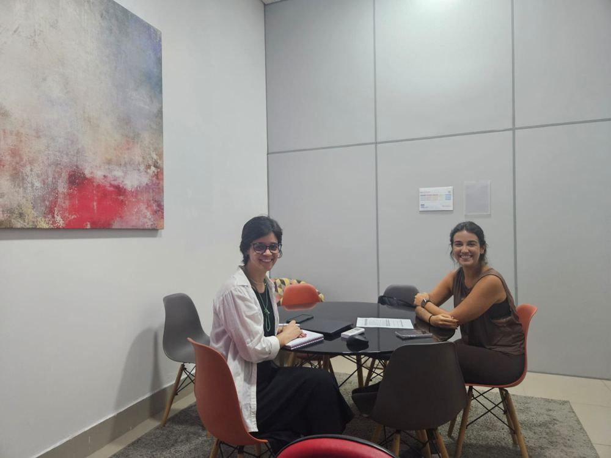

Médica Tauana

Clínicas Integradas

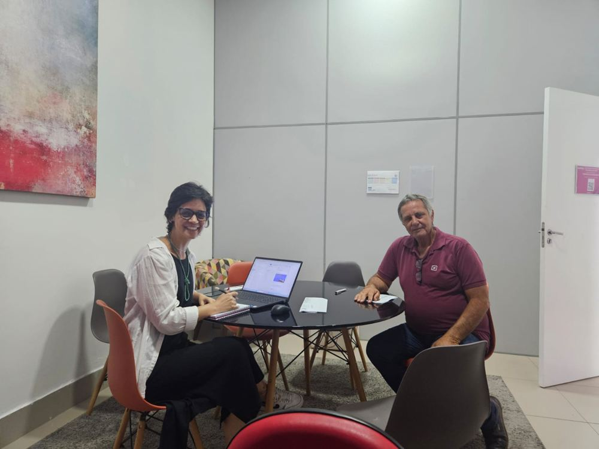

Professor Celso Lasmar

Reunião de alinhamento — Clínica Cirúrgica

Ação 2Fevereiro 2026

Recepção de Professores de Medicina e Cursos SHE

Acolhimento Docente

Ação de acolhimento e recepção de professores dos cursos de Medicina e SHE, com foco na integração institucional, apresentação inicial de orientações acadêmicas e fortalecimento do vínculo com a equipe gestora e o NAPED.

Acolhimento docente, integração institucional, professores Medicina e SHE.

Evidências

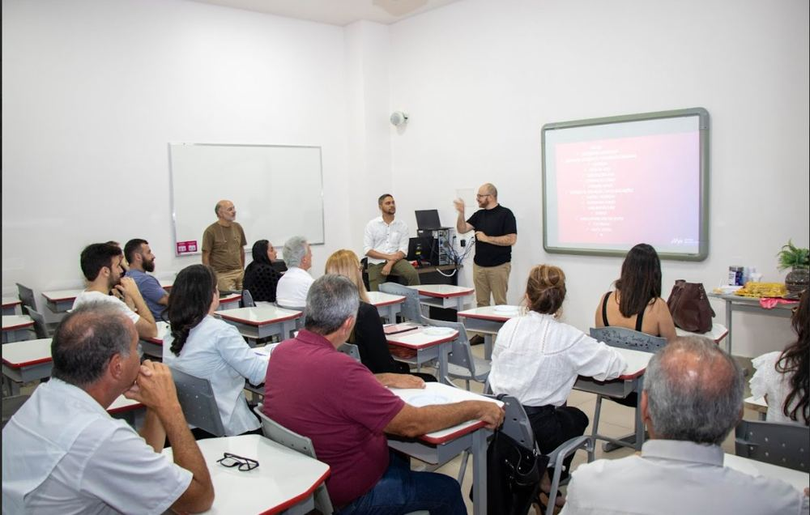

Docentes de medicina, coordenação e reitoria

Recepção de professores

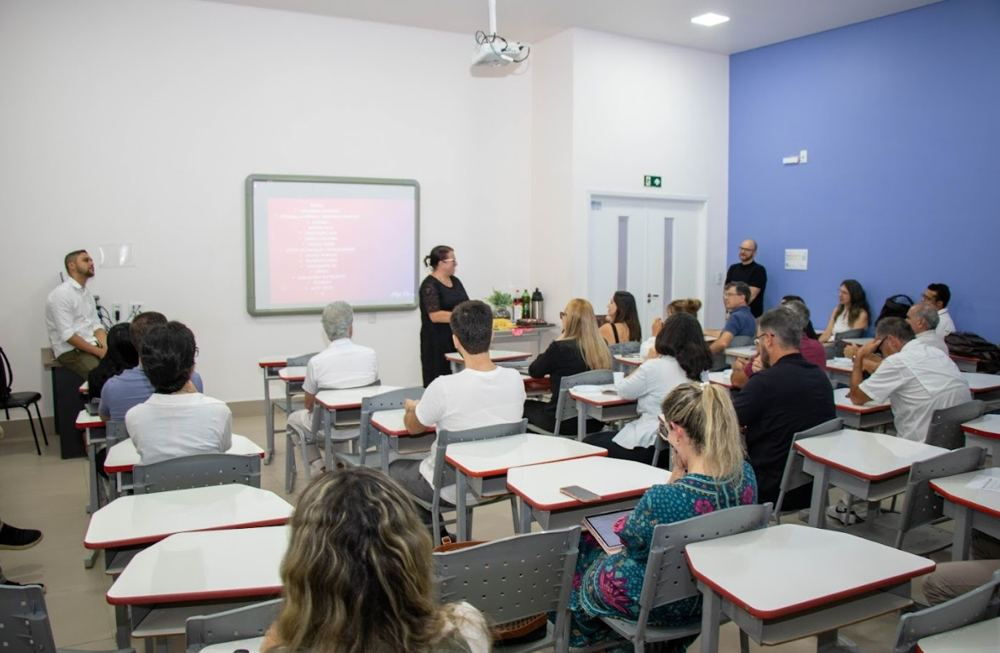

Docentes de medicina, coordenação e reitoria

Recepção de professores

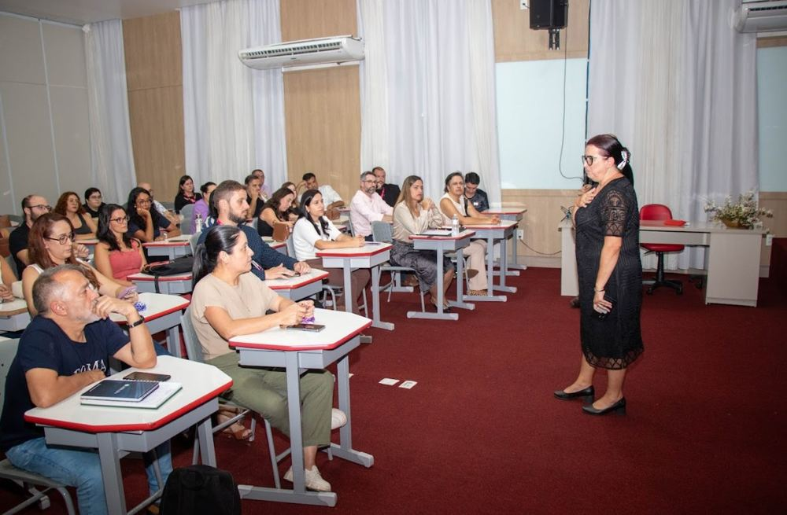

Docentes de medicina, coordenação e reitoria

Recepção de professores

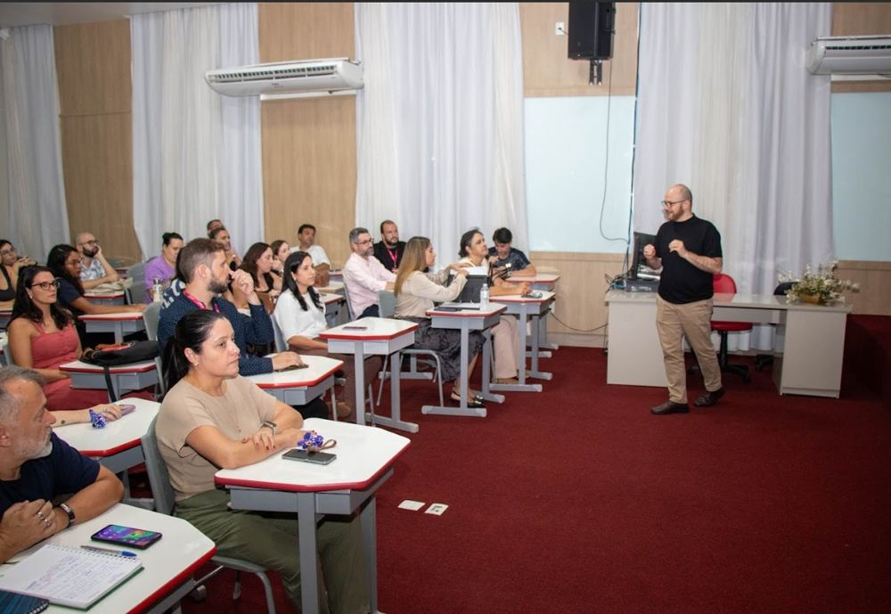

Docentes de medicina, coordenação e reitoria

Recepção de professores

Ação 3Fevereiro 2026

ENAMED

Alinhamento Institucional e Orientação aos Estudantes

Ação institucional desenvolvida por meio de reunião entre NAPED, coordenação de curso e reitoria, seguida de encontro com os estudantes, com foco no alinhamento de estratégias relacionadas ao ENAMED, sensibilização acadêmica, orientação sobre a importância do exame e fortalecimento do acompanhamento institucional ao longo do semestre.

ENAMED, alinhamento institucional, orientação aos estudantes.

Evidências

[figure not shown]

Reunião de alinhamento para as ações ENAMED

Plano de Ações ENAMED 2026

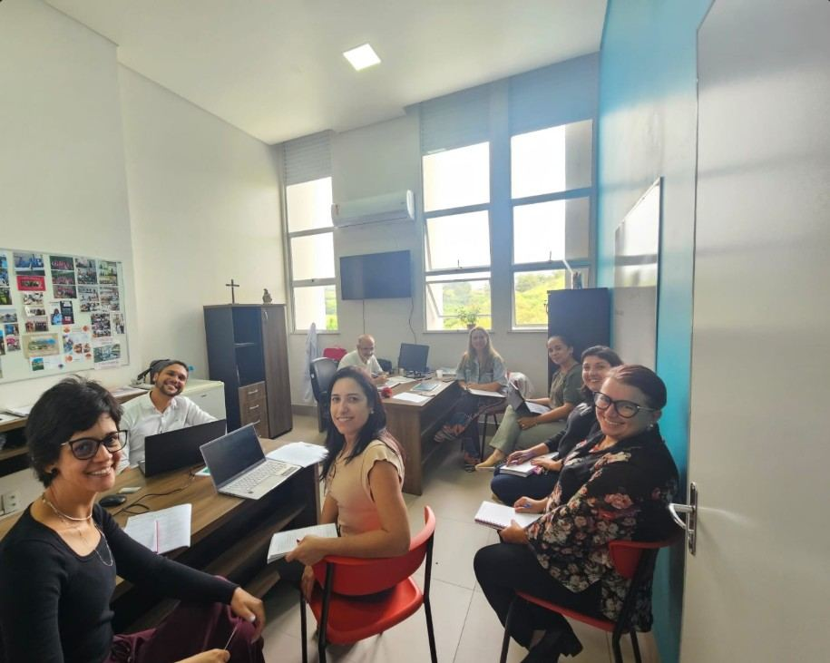

Reunião de alinhamento para as ações ENAMED

Encontro com a equipe institucional

Ação 4Fevereiro 2026

IA na Educação Médica

Acolhimento aos Calouros 2026.1

Ação de acolhimento aos estudantes ingressantes do curso de Medicina, realizada com foco na integração acadêmica e apresentação de ferramentas digitais de apoio ao estudo. Durante o encontro, os calouros participaram de treinamento introdutório sobre a plataforma NotebookLM, com orientações práticas para organização de materiais, leitura dirigida e otimização da aprendizagem.

Calouros Medicina, NotebookLM, acolhimento acadêmico.

Evidências

[figure not shown]

Calouros de medicina 2026.1

Treinamento introdutório sobre o NotebookLM

Ação 5Fevereiro 2026

Produção Científica e Engajamento Docente no XII Fórum Internacional de Inovação Acadêmica

Produção Científica · Internacionalização

Ação institucional de mobilização acadêmica voltada ao fortalecimento da produção científica e à participação de docentes e estudantes no XII Fórum Internacional de Inovação Acadêmica. A iniciativa utilizou comunicação estratégica em formato de contagem regressiva para reforçar prazos de submissão, ampliar o engajamento da comunidade acadêmica e estimular a divulgação de pesquisas, projetos e experiências exitosas desenvolvidas na instituição.

Produção científica, engajamento acadêmico, internacionalização.

Evidências

[figure not shown]

Contagem regressiva

Arte de incentivo à submissão de trabalhos no XII Fórum Internacional de Inovação Acadêmica

[figure not shown]

XII Fórum STHEM 2026

Arte oficial da campanha institucional de mobilização acadêmica — 7, 8, 9 e 10 de abril

[figure not shown]